# Bayes

UNC EPID 722: Dr. Steve Cole

February 4, 2016

**NOTE: ALL SAS code below copied from 2016 EPID 722 lecture material. SAS code based on Steve Cole’s programs titled, “program4.19jan16.sas”. All R code below is adapted to the SAS code and written by Ann Von Holle.**

### 0.0.1 Preliminaries

#### 0.0.1.1 Specify packages for R

```r
  #install.packages(c("knitr", "foreign", "tableone", "MCMCpack")) # Note: you only need to do this once. then only if you want updates.
  require(foreign)
#  require(plyr)
  require(tableone)
  require(ggplot2)
  require(MCMCpack)
  set.seed(123) # set seed so you get same results each time you run. Note, this seed in R will not give you same results as SAS seed.
```

### 0.0.2 Read file

#### 0.0.2.1 SAS

```sas
libname mle "c:\temp";
%let dir = c:\temp;

*Read ASCII file;
data mle.b;
    infile "&dir\hividu15dec15.dat";
    input id 1-4 idu 6 white 8 age 10-11 cd4 13-16 drop 18 delta 20 @22 art 6.3 @29 t 6.3;
run;


* Export to .csv for use in R;
proc export data=mle.b outfile="c:\temp\hividu15dec15.csv" dbms=csv replace; run;
```

#### 0.0.2.2 R

Read the data (created in the SAS program above).

```r
#getwd() # get the working directory
b = read.csv("c:/temp/hividu15dec15.csv", header=T) # read in data.
```

### 0.0.3 Simplify to binary outcome, delta.

#### 0.0.3.1 SAS

by IDU and overall

```sas
  libname mle "c:\temp";
  data a; set mle.b; run;

proc freq data=a;
    tables idu*delta;
    title "Injection drug use by AIDS or death";
run; quit;
```

```
## Injection drug use by AIDS or death
##
## The FREQ Procedure
##
## Table of idu by delta
##
## idu       delta
##
## Frequency|
## Percent  |
## Row Pct  |
## Col Pct  |       0|       1|  Total
## ---------+--------+--------+
##        0 |    418 |    307 |    725
##          |  35.91 |  26.37 |  62.29
##          |  57.66 |  42.34 |
##          |  71.45 |  53.02 |
## ---------+--------+--------+
##        1 |    167 |    272 |    439
##          |  14.35 |  23.37 |  37.71
##          |  38.04 |  61.96 |
##          |  28.55 |  46.98 |
## ---------+--------+--------+
## Total         585      579     1164
##             50.26    49.74   100.00
##
## Frequency Missing = 14410
```

#### 0.0.3.2 R

```r
cat.vars = c("idu")
t.one = CreateCatTable(data=b, vars=cat.vars, strata="delta", test=F)
t.one
```

```
##              Stratified by delta
##               0           1
##   n           585         579
##   idu = 1 (%) 167 (28.5)  272 (47.0)
```

### 0.0.4 Maximum Likelihood by generalized linear model

#### 0.0.4.1 SAS

```sas
  libname mle "c:\temp";
  data a; set mle.b; run;

*ML by genmod;
proc genmod data=a desc;
    model delta=idu/d=b;
    ods select modelinfo modelfit parameterestimates;
    title "ML by genmod procedure";
run; quit;
```

```
## ML by genmod procedure
##
## The GENMOD Procedure
##
##       Model Information
##
## Data Set                WORK.A
## Distribution          Binomial
## Link Function            Logit
## Dependent Variable       delta
##
##
##              Criteria For Assessing Goodness Of Fit
##
## Criterion                     DF           Value        Value/DF
##
## Log Likelihood                         -785.6131
## Full Log Likelihood                    -785.6131
## AIC (smaller is better)                1575.2261
## AICC (smaller is better)               1575.2365
## BIC (smaller is better)                1585.3454
##
##
##              Analysis Of Maximum Likelihood Parameter Estimates
##
##                          Standard       Wald 95%             Wald
## Parameter  DF  Estimate     Error   Confidence Limits  Chi-Square  Pr > ChiSq
##
## Intercept   1   -0.3086    0.0752   -0.4560   -0.1613       16.86      <.0001
## idu         1    0.7964    0.1238    0.5539    1.0390       41.42      <.0001
## Scale       0    1.0000    0.0000    1.0000    1.0000
##
## NOTE: The scale parameter was held fixed.
```

#### 0.0.4.2 R

```r
glm.0 = glm(delta ~ idu, family = "binomial"(link = logit), data=b)
summary(glm.0)
```

```
##
## Call:
## glm(formula = delta ~ idu, family = binomial(link = logit), data = b)
##
## Deviance Residuals:
##    Min      1Q  Median      3Q     Max
## -1.390  -1.049  -1.049   1.311   1.311
##
## Coefficients:
##             Estimate Std. Error z value Pr(>|z|)
## (Intercept) -0.30863    0.07516  -4.106 4.02e-05 ***
## idu          0.79644    0.12375   6.436 1.23e-10 ***
## ---
## Signif. codes:  0 '***' 0.001 '**' 0.01 '*' 0.05 '.' 0.1 ' ' 1
##
## (Dispersion parameter for binomial family taken to be 1)
##
##     Null deviance: 1613.6  on 1163  degrees of freedom
## Residual deviance: 1571.2  on 1162  degrees of freedom
## AIC: 1575.2
##
## Number of Fisher Scoring iterations: 4
```

### 0.0.5 Bayes by data augmentation, normal prior on b1, prior 95 pct CI 1/2, 2

#### 0.0.5.1 SAS

```sas
  libname mle "c:\temp";
  data a; set mle.b; run;

data priorb1;
    int=0;
    or=exp(0);
    v=.3536**2;
    f=400; *f=2/v*s**2; *f set large to ensure asymptotics;
    s=sqrt(f/(2/v));
    pair=1; idu=1/s; delta=1; offset=-log(or)/s; output; idu=0; delta=0; offset=0; output;
    pair=2; idu=0; delta=1; offset=0; output; idu=1/s; delta=0; offset=-log(or)/s; output;
run;

proc print data=priorb1; run;

proc genmod data=priorb1 desc;
    freq f;
    model delta=int idu/d=b noint offset=offset;
    ods select modelinfo modelfit parameterestimates;
    title "Prior for b1 by data augmentation";
run;

data a;
    set a;
    int=1;
    f=1;
    offset=0;
run;

data both;
    set a priorb1;
run;

proc genmod data=both desc;
    freq f;
    model delta=int idu/d=b noint offset=offset;
    ods select modelinfo modelfit parameterestimates;
    title "Posterior for b1 by data augmentation";
run; quit;
```

```
## Obs   int   or      v       f       s      pair     idu     delta   offset
##
##  1     0     1   0.12503   400   5.00066     1    0.19997     1        0
##  2     0     1   0.12503   400   5.00066     1    0.00000     0        0
##  3     0     1   0.12503   400   5.00066     2    0.00000     1        0
##  4     0     1   0.12503   400   5.00066     2    0.19997     0        0
##
##
##
## Prior for b1 by data augmentation
##
## The GENMOD Procedure
##
##             Model Information
##
## Data Set                     WORK.PRIORB1
## Distribution                     Binomial
## Link Function                       Logit
## Dependent Variable                  delta
## Frequency Weight Variable               f
## Offset Variable                    offset
##
##
##              Criteria For Assessing Goodness Of Fit
##
## Criterion                     DF           Value        Value/DF
##
## Log Likelihood                        -1109.0355
## Full Log Likelihood                   -1109.0355
## AIC (smaller is better)                2220.0710
## AICC (smaller is better)               2220.0735
## BIC (smaller is better)                2225.4487
##
##
##              Analysis Of Maximum Likelihood Parameter Estimates
##
##                          Standard       Wald 95%             Wald
## Parameter  DF  Estimate     Error   Confidence Limits  Chi-Square  Pr > ChiSq
##
## Intercept   0    0.0000    0.0000    0.0000    0.0000         .         .
```

[output cut: 29 more lines]

```
## AICC (smaller is better)               3797.8193
## BIC (smaller is better)                3809.6639
##
##
##              Analysis Of Maximum Likelihood Parameter Estimates
##
##                          Standard       Wald 95%             Wald
## Parameter  DF  Estimate     Error   Confidence Limits  Chi-Square  Pr > ChiSq
##
## Intercept   0    0.0000    0.0000    0.0000    0.0000         .         .
## int         1   -0.2767    0.0735   -0.4207   -0.1327       14.18      0.0002
## idu         1    0.7100    0.1163    0.4820    0.9381       37.25      <.0001
## Scale       0    1.0000    0.0000    1.0000    1.0000
##
## NOTE: The scale parameter was held fixed.
```

#### 0.0.5.2 R

```r
int.0 = 0; or.0 = exp(0); v.0 = 0.3536^2; f.0 = 400; s.0 = sqrt(f.0/(2/v.0)) # set scalars
# f = 2/(v*s^2), f set large to ensure asymptotics

combos = data.frame(rbind(c(pair=1, idu=1/s.0, delta=1),
                          c(pair=1, idu=0, delta=0),
                          c(pair=2, idu=0, delta=1),
                          c(pair=2, idu=1/s.0, delta=0)
                    ))

priorb1 = data.frame(int=int.0,
                     or=or.0, # or and v variables are extra data. v=variance is set by subject matter knowledge.
                     v=v.0,
                     f=f.0,
                     s=s.0, # using other info, f=2/(v*s^2), calculate s. s=sqrt(2/(f*v))?
                     combos,
                     offset=0)

priorb1
```

```
##   int or        v   f        s pair       idu delta offset
## 1   0  1 0.125033 400 5.000659    1 0.1999736     1      0
## 2   0  1 0.125033 400 5.000659    1 0.0000000     0      0
## 3   0  1 0.125033 400 5.000659    2 0.0000000     1      0
## 4   0  1 0.125033 400 5.000659    2 0.1999736     0      0
```

Prior for b1 by data augmentation

```r
  glm.1 =  glm(delta ~ int + idu - 1 + offset(offset), #Note: whenever you have a null based prior you don't need an offset.
               family="binomial"(link=logit),
               weights = f, data=priorb1)
  summary(glm.1)
```

```
##
## Call:
## glm(formula = delta ~ int + idu - 1 + offset(offset), family = binomial(link = logit),
##     data = priorb1, weights = f)
##
## Deviance Residuals:
##      1       2       3       4
##  23.55  -23.55   23.55  -23.55
##
## Coefficients: (1 not defined because of singularities)
##      Estimate Std. Error z value Pr(>|z|)
## int        NA         NA      NA       NA
## idu 1.256e-15  3.536e-01       0        1
##
## (Dispersion parameter for binomial family taken to be 1)
##
##     Null deviance: 2218.1  on 4  degrees of freedom
## Residual deviance: 2218.1  on 3  degrees of freedom
## AIC: 2220.1
##
## Number of Fisher Scoring iterations: 2
```

**Note** that the standard error for the $\beta_1$ parameter, for **idu**, matches that of the sqrt(v.0) estimate, 0.3536.

```r
  names(coef(glm.1))
```

```
## [1] "int" "idu"
```

```r
  coef(glm.1)[2]
```

```
##         idu
## 1.25624e-15
```

Append priorb1 to the original data set, b

```r
    b = within(b, {
      int=1; f=1; offset=0
    })

    reg.vars = c("int", "f", "offset", "idu", "delta", "f")
    both = rbind(b[, colnames(b) %in% reg.vars],
                 priorb1[colnames(priorb1) %in% reg.vars])
    both$offset = 0
    tail(both)
```

```
##            idu delta offset   f int
## 1163 0.0000000     1      0   1   1
## 1164 0.0000000     0      0   1   1
## 1165 0.1999736     1      0 400   0
## 1166 0.0000000     0      0 400   0
## 1167 0.0000000     1      0 400   0
## 1168 0.1999736     0      0 400   0
```

Generalized linear model with posterior for $\beta_1$ by data augmentation.

```r
  glm.2 = glm(delta ~ int + idu - 1 + offset(offset),
              family="binomial"(link=logit),
              weights = f, data = both)

  summary(glm.2)
```

```
##
## Call:
## glm(formula = delta ~ int + idu - 1 + offset(offset), family = binomial(link = logit),
##     data = both, weights = f)
##
## Deviance Residuals:
##     Min       1Q   Median       3Q      Max
## -24.765   -1.062   -1.062    1.297   23.548
##
## Coefficients:
##     Estimate Std. Error z value Pr(>|z|)
## int -0.27668    0.07348  -3.765 0.000166 ***
## idu  0.71004    0.11634   6.103 1.04e-09 ***
## ---
## Signif. codes:  0 '***' 0.001 '**' 0.01 '*' 0.05 '.' 0.1 ' ' 1
##
## (Dispersion parameter for binomial family taken to be 1)
##
##     Null deviance: 3831.7  on 1168  degrees of freedom
## Residual deviance: 3793.8  on 1166  degrees of freedom
## AIC: 3797.8
##
## Number of Fisher Scoring iterations: 4
```

Note that the $\beta_1$ estimate, 0.71, is pulled from the estimated coefficient from the observed data, 0.7964, toward the prior, log(or) = log(1) = 0. Also note that there is a smaller standard error for $\beta_1$ because there are more data points.

### 0.0.6 Bayes by MCMC

#### 0.0.6.1 SAS

```sas
  %let dir=c:\temp;
  libname mle "&dir.";
  data a; set mle.b; run;

data priors;
    input _type_ $ _name_:$9. Intercept idu;
    cards;
    mean . 0   0
    cov  Intercept 100 0
    cov  idu       0   0.125
;
run;

proc print data=priors; run;

*NOTE: having an issue running this in SAS batch mode with the bayes statement. Please refer to SAS program, "program4.19jan16.sas", run in SAS for output below.
*   intercept mean = -0.2795 and
    idu mean = 0.7101;

      ods listing gpath="&dir/";
ods graphics on /reset=all imagename="Trace" imagefmt=jpeg height=8in width=8in;
proc genmod data=a desc;
    model delta=idu/d=b;
    bayes seed=123 nbi=500 nmc=2000 coeffprior=normal(input=priors);
    ods select modelinfo postsummaries tadpanel;
    ods output posteriorsample=post(keep=iteration idu);
    title "Bayes by genmod procedure";

*What is the probabuility that OR>1?;

    data post2; set post; if exp(idu)>1 then por=1; else por=0; run;
    proc means data=post2; var iteration idu por; run; * Note: all draws have exp(idu) greater than 1;

* Next try exp(idu)>2; * that is around 0.55;

    data post3; set post; if exp(idu)>2 then por=1; else por=0; run;
    proc means data=post3; var iteration idu por; run; * Note: all draws have exp(idu) greater than 1;

*What strength of null-prior would make this association not statistically significant?;
*What strength of null-prior would make this point estimate not larger than 1.2?;
*I did not include Bayes by rejection sampling, why not?;
run; quit; run;
```

| Posterior for b1 by data augmentation |
| --- |

| Obs | *type* | *name* | Intercept | idu |
| --- | --- | --- | --- | --- |
| 1 | mean |  | 0 | 0.000 |
| 2 | cov | Intercept | 100 | 0.000 |
| 3 | cov | idu | 0 | 0.125 |

| Bayes by genmod procedure |
| --- |

The GENMOD Procedure

Bayesian Analysis

| Model Information |  |
| --- | --- |
| Data Set | WORK.A |
| Burn-In Size | 500 |
| MC Sample Size | 2000 |
| Thinning | 1 |
| Sampling Algorithm | Gamerman |
| Distribution | Binomial |
| Link Function | Logit |
| Dependent Variable | delta |

| Bayes by genmod procedure |
| --- |

The GENMOD Procedure

Bayesian Analysis

| Posterior Summaries Parameter | Posterior Summaries N | Posterior Summaries Mean | Posterior Summaries Standard Deviation | Posterior Summaries Percentiles 25% | Posterior Summaries Percentiles 50% | Posterior Summaries Percentiles 75% |
| --- | --- | --- | --- | --- | --- | --- |
| Intercept | 2000 | -0.2795 | 0.0714 | -0.3278 | -0.2791 | -0.2310 |
| idu | 2000 | 0.7101 | 0.1141 | 0.6364 | 0.7097 | 0.7892 |

| Bayes by genmod procedure |
| --- |

The GENMOD Procedure

Bayesian Analysis

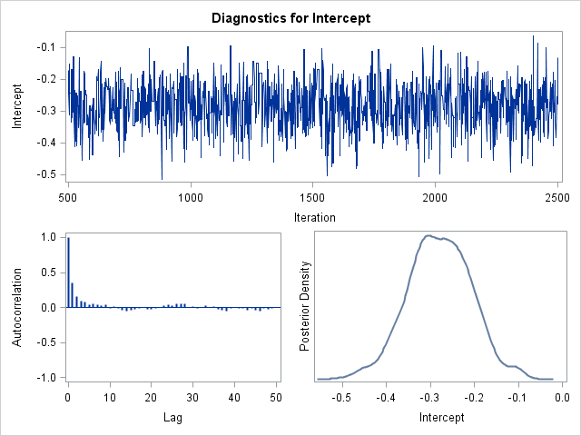

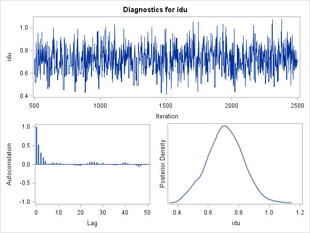

#### 0.0.6.2 R

```r
    # for another comparison of SAS and R see http://www.r-bloggers.com/example-8-17-logistic-regression-via-mcmc/

    precision = matrix( c(100^-1, 0, 0, 0.125^-1), nrow=2, byrow=T) # see documentation for MCMClogit package for the parameterization of the Normal prior on beta
    # In this example, in data augmentation there was no information on variance.

    log.mcmc = MCMClogit(delta ~ idu, data=b,
                       burnin=500, mcmc=2000,
                       b0=c(0,0), B0=precision)
    # see http://sas-and-r.blogspot.com/2010/12/example-817-logistic-regression-via.html

    summary(log.mcmc)
```

```
##
## Iterations = 501:2500
## Thinning interval = 1
## Number of chains = 1
## Sample size per chain = 2000
##
## 1. Empirical mean and standard deviation for each variable,
##    plus standard error of the mean:
##
##                Mean      SD Naive SE Time-series SE
## (Intercept) -0.2691 0.06899 0.001543       0.004332
## idu          0.7080 0.11085 0.002479       0.007122
##
## 2. Quantiles for each variable:
##
##                2.5%     25%     50%     75%   97.5%
## (Intercept) -0.4141 -0.3175 -0.2673 -0.2180 -0.1431
## idu          0.4948  0.6299  0.7066  0.7857  0.9091
```

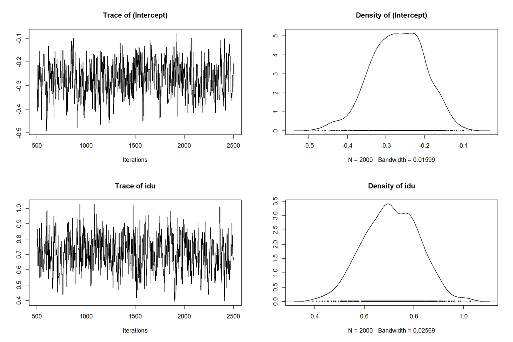

```r
    plot(log.mcmc)
```

### 0.0.7 Demo for offsets

Offset: predictor variable with coefficient set to 1 (http://bit.ly/1THAKuX)

Example of an offset = log Z in intercept-only logistic regression model:

$\begin{align*} log(p/(1-p)) &= \beta_0 + log(Z) \\ log(p/(1-p)) - log(Z) &= \beta_0 \\ log( \frac{p/(1-p)}{Z} ) &= \beta_0 \\ \frac{p/(1-p)}{Z} &= exp(\beta_0) = log(odds) \end{align*}$

```r
set.seed(1235)
```

#### 0.0.7.1 Create some simulated data for logistic regression model

```r
    num = 1000 # sample size
    beta.0 = 0.5; beta.1 = 1.3;  # model parameters
    x.1 = rnorm(num) # single covariate in model
    lp.1 = beta.0 + beta.1*x.1 # linear predictor
    plogis.1 = 1/(1+exp(-lp.1)); plogis.1[1] # probability of outcome
```

```
## [1] 0.3995395
```

```r
    #plogis.1 = plogis(lp.1); plogis.1[1] # shortcut function to get probability
    y.out = rbinom(num, 1, plogis.1) # generate random 0/1 based on probability
    table(y.out) # check values
```

```
## y.out
##   0   1
## 387 613
```

```r
    Z = 1.2
    offset.1 = log(Z); offset.1
```

```
## [1] 0.1823216
```

```r
    df.1 = data.frame(y.out, x.1, int=1, offset.1) # make data frame with simulated values
```

#### 0.0.7.2 Run logistic model with no offset

```r
    glm.0 = glm(y.out ~ x.1,
                family=binomial(link="logit"),
                data=df.1)
    coef(glm.0)
```

```
## (Intercept)         x.1
##   0.5931785   1.3030461
```

**Comment**:

As expected, the estimated intercept from the simulated data, 0.5932, is close (enough) to the specified $\beta_0$ parameter = 0.5. The estimated coefficient for $\beta_1$, 1.303, from the simulated data is close to the specified $\beta_1$ parameter value in the simulation of 1.3.

#### 0.0.7.3 Run logistic regression model with offset

```r
    glm.1 = glm(y.out ~ -1 + int + x.1 + offset(offset.1),
                family=binomial(link="logit"),
                data=df.1)
    coef(glm.1)
```

```
##      int      x.1
## 0.410857 1.303046
```

**Comment**:

*Model with offset (ignoring the $\beta_1$ term)*: $\begin{align*} log(p/(1-p)) = \beta_0^{\prime} + log(Z) \\ \textrm{where p/(1-p) is from observed data and } exp(\beta_0) = 1.8097. \\ log(exp(0.5932)) &= 0.4109 + log(1.2) \\ log(1.8097) - log(1.2) &= 0.4109 \\ log\left(\frac{1.8097}{1.2}\right) &= 0.4109 \\ log(1.5081) &= 0.4109 \\ 0.4109 &= 0.4109 \end{align*}$

Now you have added in an offset, offset.1 = log(Z) = log(1.2) = 0.1823. Given the formula at the start of the offset section above, the adjusted odds should be $\frac{p/(1-p)}{Z}$ = $\frac{1.8097}{1.2}$ = 1.5081. Then the intercept, log(odds) for the referent group of the x.1 variable, should be log(1.5081) = 0.4109. The intercept for the model with the offset, glm.1, is that value, 0.410857. Also, note that the coefficient for $\beta_1$ is the same across models with and without an offset.

This example demonstrates that the offset Z adjusts the intercept of the observed data. In this example a Z>1 moves the intercept in the logisitic regression downward from 0.5932 to 0.4109

Assigned reading

1. Cole SR, Chu H, Greenland S, et al. Bayesian Posterior Distributions Without Markov Chains. *Am. J. Epidemiol.* [electronic article]. 2012;175(5):368–375. (http://aje.oxfordjournals.org/cgi/doi/10.1093/aje/kwr433)